# BioIn_2025_09_v3.3.1_fgsea_BSS_tut.Rmd

Stephanie Huang

2025-09-22

# **Easy Gene Set Enrichment Analysis in R with fgsea()**

**Tutorial generally follows Biostatsquid blog but also uses the pnnl (GSEA 8.3) one & elements of AnnotationsDbi documentation.**

- https://bioconductor.org/packages/release/bioc/html/fgsea.html
- https://biostatsquid.com/fgsea-tutorial-gsea/
- Other useful details
  - https://biostatsquid.com/pathway-enrichment-analysis-explained/
  - https://igordot.github.io/msigdbr/articles/msigdbr-intro.html
  - https://pnnl-comp-mass-spec.github.io/proteomics-data-analysis-tutorial/gsea.html
  - [Introduction To Bioconductor Annotation Packages](https://bioconductor.org/packages/release/bioc/html/AnnotationDbi.html)
  - [A novel significance score for gene selection and ranking](https://pmc.ncbi.nlm.nih.gov/articles/PMC3957066/)

Using data from 2025_09_12_rp_1pspg_test_pairwise_msstats_v3.1.5_t8.csv computed via R script ‘MSstatsTMT_2025_09_v3.1.5_rp_1pspg_PSMs_from_2025_08.R in JSRProteomics > MSstatsTMT > v3 on 2025-09-12’

### 2025-09-22 Interim Summary

- Tested basic GSEA using fgsea() using MSigDB Mouse Hallmark Genesets (50). Prepared using gene symbols.
  - Gene symbols mapped with AnnotationDbi & org.. Rn.eg.db (assuming rat & mice are the same - fix later).
  - Set up protein list from MSstatTMT 3.1.5 t8 Housing - EE vs SH (1pspg) - e.g. trimmed any col with issues, or missing pvalues, proteins with Cont_. Went from 7746 to 7724.
  - Annotated protein list with gene symbols + EntrezID, gene name, etc. Why 7780?
  - Then ranked using sign(log2fc)*(-log10(pval) - resulted in 7153 ranked genes available for fgsea(). Made into vector for basic fgsea()
  - Ran basic fgsea() with ranked list, mouse hallmark geneset, min 15, max 500. Note slightly different ranking cause based on setting different & also write_csv does not properly write out leading edge column.
  - Visualised with fgsea plotGseaTable() to plot top 15 paths & did plotEnrichment for 4/5 top ones.

#### To look into/fix

1. Look Proteins that fail to map onto genes (around 8%).
2. Look at which gene IDs to convert to & use.
3. Look into why annotated list gets bigger - 7724 to 7780
4. Look at other MSigDB genesets (e.g. brain/neuro/synaptic & development etc)
5. Look into ranking metric (e.g. comp to just log2FC, also adj.p-val vs p-val)
6. Look at saving file to keep leading edge.
7. Look at other fgsea settings & comps (e.g. fgseaMultilevel & collapsePathways)
8. Look at other plot types
9. look at other saving files etc

## Setup

Install if needed

```r
# if (!require("BiocManager", quietly = TRUE))
#     install.packages("BiocManager")
#
# BiocManager::install("fgsea")
# BiocManager::install("msigdbr")
# BiocManager::install("org.Rn.eg.db")
# BiocManager::install("org.Hs.eg.db")
```

Clean environment & Set seed - skipped

Load Packages

```r
library(org.Rn.eg.db) # Rat genome annotation package
library(org.Hs.eg.db) # human genome annotation package
# library(AnnotationDbi) # technically already loaded with org.Rn.eg.db
library(fgsea) # for gsea
library(msigdbr) # for genesets
library(dplyr) # wrangling etc, %>%, filter(), select() - conflict w/ some AnnotationDbi
library(readr) # for read_csv()
library(stringr) # for str_detect()
library(ggplot2) # for ggplot()
```

Set paths (not really needed here) - skipped

## fgsea

fgsea() takes two main parameters

1. Pathways - a list of gene sets or pathways to check
2. Statistics - a named vector of our genes of interest we want to perform gsea on.
   1. These must match the ones for the pathways (e.g. ENTREZ or gene names).

Additional Parameters

- minSize - minimal size of a gene set to test (all pathways that are less than are excluded).
- maxSize - maximum size of a gene set to test.
- scoreType - the default is std (normal enrichment score).
  - But can also do one tail if only interested in positive (over-represented) or negative enrichment (underepresented).

### 1. Prepare genesets/pathways

Note this follows the web tutorial rather than the youtube tutorial.

#### Get your gene set .gmt file via msigdbr package - [see article](https://igordot.github.io/msigdbr/articles/msigdbr-intro.html)

```r
# # msigdbr helper functions
#
# msigdbr_species() # 20 species
# msigdbr_collections() # 33730584 bytes?
#
# # check version
# unique(msigdbr_df$db_version)
#
# #how to cite
# citation("msigdbr")
```

#### Prepare Background Genes

Need set of background genes that are only present in our df to reduce bias.

Using mouse collection since gene symbols are lower case (similar to rats)

Note humans have capitalized gene symbols!

```r
# mouse & hallmark category/collection
gene_sets_df <- msigdbr(species = 'Mus musculus',
                        collection = 'H')
```

```
## Using human MSigDB with ortholog mapping to mouse. Use `db_species = "MM"` for mouse-native gene sets.
```

```r
# Using human MSigDB with ortholog mapping to mouse. Use `db_species = "MM"` for mouse-native gene sets.

# gene_sets_df <- msigdbr(species = 'Homo sapiens',
#                         category = 'C5',
#                         subcollection = 'GO:BP')

head(gene_sets_df)
```

```
## # A tibble: 6 × 23
##   gene_symbol ncbi_gene ensembl_gene db_gene_symbol db_ncbi_gene db_ensembl_gene
##   <chr>       <chr>     <chr>        <chr>          <chr>        <chr>
## 1 Abca1       11303     ENSMUSG0000… ABCA1          19           ENSG00000165029
## 2 Abcb8       74610     ENSMUSG0000… ABCB8          11194        ENSG00000197150
## 3 Acaa2       52538     ENSMUSG0000… ACAA2          10449        ENSG00000167315
## 4 Acadl       11363     ENSMUSG0000… ACADL          33           ENSG00000115361
## 5 Acadm       11364     ENSMUSG0000… ACADM          34           ENSG00000117054
## 6 Acads       11409     ENSMUSG0000… ACADS          35           ENSG00000122971
## # ℹ 17 more variables: source_gene <chr>, gs_id <chr>, gs_name <chr>,
## #   gs_collection <chr>, gs_subcollection <chr>, gs_collection_name <chr>,
## #   gs_description <chr>, gs_source_species <chr>, gs_pmid <chr>,
## #   gs_geoid <chr>, gs_exact_source <chr>, gs_url <chr>, db_version <chr>,
## #   db_target_species <chr>, ortholog_taxon_id <int>, ortholog_sources <chr>,
## #   num_ortholog_sources <dbl>
```

```r
str(gene_sets_df)
```

```
## tibble [7,379 × 23] (S3: tbl_df/tbl/data.frame)
##  $ gene_symbol         : chr [1:7379] "Abca1" "Abcb8" "Acaa2" "Acadl" ...
##  $ ncbi_gene           : chr [1:7379] "11303" "74610" "52538" "11363" ...
##  $ ensembl_gene        : chr [1:7379] "ENSMUSG00000015243" "ENSMUSG00000028973" "ENSMUSG00000036880" "ENSMUSG00000026003" ...
##  $ db_gene_symbol      : chr [1:7379] "ABCA1" "ABCB8" "ACAA2" "ACADL" ...
##  $ db_ncbi_gene        : chr [1:7379] "19" "11194" "10449" "33" ...
##  $ db_ensembl_gene     : chr [1:7379] "ENSG00000165029" "ENSG00000197150" "ENSG00000167315" "ENSG00000115361" ...
##  $ source_gene         : chr [1:7379] "ABCA1" "ABCB8" "ACAA2" "ACADL" ...
##  $ gs_id               : chr [1:7379] "M5905" "M5905" "M5905" "M5905" ...
##  $ gs_name             : chr [1:7379] "HALLMARK_ADIPOGENESIS" "HALLMARK_ADIPOGENESIS" "HALLMARK_ADIPOGENESIS" "HALLMARK_ADIPOGENESIS" ...
##  $ gs_collection       : chr [1:7379] "H" "H" "H" "H" ...
##  $ gs_subcollection    : chr [1:7379] "" "" "" "" ...
##  $ gs_collection_name  : chr [1:7379] "Hallmark" "Hallmark" "Hallmark" "Hallmark" ...
##  $ gs_description      : chr [1:7379] "Genes up-regulated during adipocyte differentiation (adipogenesis)." "Genes up-regulated during adipocyte differentiation (adipogenesis)." "Genes up-regulated during adipocyte differentiation (adipogenesis)." "Genes up-regulated during adipocyte differentiat…
##  $ gs_source_species   : chr [1:7379] "HS" "HS" "HS" "HS" ...
##  $ gs_pmid             : chr [1:7379] "26771021" "26771021" "26771021" "26771021" ...
##  $ gs_geoid            : chr [1:7379] "" "" "" "" ...
##  $ gs_exact_source     : chr [1:7379] "" "" "" "" ...
##  $ gs_url              : chr [1:7379] "" "" "" "" ...
##  $ db_version          : chr [1:7379] "2025.1.Hs" "2025.1.Hs" "2025.1.Hs" "2025.1.Hs" ...
##  $ db_target_species   : chr [1:7379] "HS" "HS" "HS" "HS" ...
##  $ ortholog_taxon_id   : int [1:7379] 10090 10090 10090 10090 10090 10090 10090 10090 10090 10090 ...
##  $ ortholog_sources    : chr [1:7379] "EggNOG|Ensembl|HGNC|HomoloGene|Inparanoid|NCBI|OMA|OrthoDB|OrthoMCL|Panther|Treefam" "EggNOG|Ensembl|HGNC|HomoloGene|Inparanoid|NCBI|OMA|OrthoDB|OrthoMCL|Panther|PhylomeDB|Treefam" "EggNOG|Ensembl|HGNC|HomoloGene|Inparanoid|NCBI|OMA|OrthoDB|OrthoMCL|Panther|…
##  $ num_ortholog_sources: num [1:7379] 11 12 11 12 12 11 11 12 12 12 ...
```

Convert gene sets into a format required for fgsea

```r
# convert in 2 name list format required for fgsea()

# Splits in separate lists containing gene symbols grouped by the geneset name (gs_name)
gene_sets <- gene_sets_df %>%
  split(x = .$gene_symbol, f = .$gs_name)

# prints out no. of loaded gene sets (can remove code if desired)
cat(paste("Loaded", length(gene_sets), "gene sets\n"))
```

```
## Loaded 50 gene sets
```

### 2. Prepare protein lists to gene IDs

Instructions/Guidance - https://biostatsquid.com/pathway-enrichment-analysis-explained/

#### Import Protein List

```r
# set working direction to source file location

# read in protein list df from MSstatsTMT comparison
df <- read_csv("input/protein_lists/2025_09_12_rp_1pspg_test_pairwise_msstats_v3.1.5_t8.csv")
```

```
## ──────────────────────────────────────────────────────── Delimiter: "," chr
## (3): Protein, Label, issue dbl (6): ...1, log2FC, SE, DF, pvalue, adj.pvalue
```

```r
head(df) # peak
```

```
## # A tibble: 6 × 9
##    ...1 Protein    Label     log2FC     SE    DF  pvalue adj.pvalue issue
##   <dbl> <chr>      <chr>      <dbl>  <dbl> <dbl>   <dbl>      <dbl> <chr>
## 1     1 A0A096MJ11 EE vs SH  0.0145 0.0369  32.3 0.697        0.934 <NA>
## 2     2 A0A096MJ32 EE vs SH -0.354  0.151   12   0.0365       0.536 <NA>
## 3     3 A0A096MJ78 EE vs SH -0.0986 0.0317  57.7 0.00288      0.306 <NA>
## 4     4 A0A096MJ94 EE vs SH -0.0598 0.182   12   0.749        0.950 <NA>
## 5     5 A0A096MJ99 EE vs SH -0.0497 0.0329  51.4 0.138        0.696 <NA>
## 6     6 A0A096MJA9 EE vs SH  0.0167 0.0590  46.4 0.778        0.955 <NA>
```

```r
str(df) # structure
```

```
## spc_tbl_ [7,746 × 9] (S3: spec_tbl_df/tbl_df/tbl/data.frame)
##  $ ...1      : num [1:7746] 1 2 3 4 5 6 7 8 9 10 ...
##  $ Protein   : chr [1:7746] "A0A096MJ11" "A0A096MJ32" "A0A096MJ78" "A0A096MJ94" ...
##  $ Label     : chr [1:7746] "EE vs SH" "EE vs SH" "EE vs SH" "EE vs SH" ...
##  $ log2FC    : num [1:7746] 0.0145 -0.3543 -0.0986 -0.0598 -0.0497 ...
##  $ SE        : num [1:7746] 0.0369 0.1505 0.0317 0.1825 0.0329 ...
##  $ DF        : num [1:7746] 32.3 12 57.7 12 51.4 ...
##  $ pvalue    : num [1:7746] 0.69717 0.0365 0.00288 0.74896 0.13751 ...
##  $ adj.pvalue: num [1:7746] 0.934 0.536 0.306 0.95 0.696 ...
##  $ issue     : chr [1:7746] NA NA NA NA ...
##  - attr(*, "spec")=
##   .. cols(
##   ..   ...1 = col_double(),
##   ..   Protein = col_character(),
##   ..   Label = col_character(),
##   ..   log2FC = col_double(),
##   ..   SE = col_double(),
##   ..   DF = col_double(),
##   ..   pvalue = col_double(),
##   ..   adj.pvalue = col_double(),
##   ..   issue = col_character()
##   .. )
##  - attr(*, "problems")=<externalptr>
```

```r
colnames(df) # column names
```

```
## [1] "...1"       "Protein"    "Label"      "log2FC"     "SE"
## [6] "DF"         "pvalue"     "adj.pvalue" "issue"
```

```r
dim(df)
```

```
## [1] 7746    9
```

```r
# lil checks (bit messy)
unique(df$issue) # if = na in issue column then good. if not exclude
```

```
## [1] NA                    "oneConditionMissing"
```

```r
df %>% filter(str_detect(Protein, "Cont_")) # rows with contaminants - to exlude
```

```
## # A tibble: 21 × 9
##     ...1 Protein     Label      log2FC     SE    DF pvalue adj.pvalue issue
##    <dbl> <chr>       <chr>       <dbl>  <dbl> <dbl>  <dbl>      <dbl> <chr>
##  1  1875 Cont_O77727 EE vs SH  0.112   0.208   12   0.598       0.904 <NA>
##  2  1876 Cont_P00761 EE vs SH -0.0316  0.0486  51.3 0.519       0.882 <NA>
##  3  1877 Cont_P00883 EE vs SH -0.0477  0.0545  12   0.398       0.845 <NA>
##  4  1878 Cont_P02769 EE vs SH -0.102   0.134   54.5 0.449       0.864 <NA>
##  5  1879 Cont_P04264 EE vs SH -0.336   0.213   51.4 0.121       0.682 <NA>
##  6  1880 Cont_P09870 EE vs SH  0.0783  0.173   12   0.659       0.921 <NA>
##  7  1881 Cont_P13645 EE vs SH -0.386   0.180   53.6 0.0369      0.538 <NA>
##  8  1882 Cont_P19012 EE vs SH -0.0800  0.108   12   0.474       0.871 <NA>
##  9  1883 Cont_P30879 EE vs SH  0.0168  0.0297  40.0 0.576       0.897 <NA>
## 10  1884 Cont_P34955 EE vs SH -0.00468 0.0900  12   0.959       0.990 <NA>
## # ℹ 11 more rows
```

```r
df %>% filter(str_detect(log2FC, "Inf")) # rows with Infinity /no log fold - to exclude
```

```
## # A tibble: 1 × 9
##    ...1 Protein    Label    log2FC    SE    DF pvalue adj.pvalue issue
##   <dbl> <chr>      <chr>     <dbl> <dbl> <dbl>  <dbl>      <dbl> <chr>
## 1   134 A0A0G2JYB7 EE vs SH    Inf    NA    NA     NA         NA oneConditionMi…
```

```r
df %>% filter(is.na(pvalue)) # same observation as the "Inf" in log2FC
```

```
## # A tibble: 1 × 9
##    ...1 Protein    Label    log2FC    SE    DF pvalue adj.pvalue issue
##   <dbl> <chr>      <chr>     <dbl> <dbl> <dbl>  <dbl>      <dbl> <chr>
## 1   134 A0A0G2JYB7 EE vs SH    Inf    NA    NA     NA         NA oneConditionMi…
```

```r
df %>% filter(is.na(adj.pvalue)) # same observation as the "Inf" in log2FC
```

```
## # A tibble: 1 × 9
##    ...1 Protein    Label    log2FC    SE    DF pvalue adj.pvalue issue
##   <dbl> <chr>      <chr>     <dbl> <dbl> <dbl>  <dbl>      <dbl> <chr>
## 1   134 A0A0G2JYB7 EE vs SH    Inf    NA    NA     NA         NA oneConditionMi…
```

#### Clean up protein list

```r
protein_list <- df %>%
  filter(is.na(issue)) %>% # keeps rows with issue == na
  filter(!str_detect(Protein, "Cont_")) %>% # removes contaminants
  filter(!str_detect(log2FC, "Inf")) %>% # removes missing log value.
  dplyr::select(Protein:adj.pvalue) # rm weird ...1 col & issue col, can prob skip this


head(protein_list)
```

```
## # A tibble: 6 × 7
##   Protein    Label     log2FC     SE    DF  pvalue adj.pvalue
##   <chr>      <chr>      <dbl>  <dbl> <dbl>   <dbl>      <dbl>
## 1 A0A096MJ11 EE vs SH  0.0145 0.0369  32.3 0.697        0.934
## 2 A0A096MJ32 EE vs SH -0.354  0.151   12   0.0365       0.536
## 3 A0A096MJ78 EE vs SH -0.0986 0.0317  57.7 0.00288      0.306
## 4 A0A096MJ94 EE vs SH -0.0598 0.182   12   0.749        0.950
## 5 A0A096MJ99 EE vs SH -0.0497 0.0329  51.4 0.138        0.696
## 6 A0A096MJA9 EE vs SH  0.0167 0.0590  46.4 0.778        0.955
```

```r
dim(protein_list)
```

```
## [1] 7724    7
```

```r
str(protein_list)
```

```
## tibble [7,724 × 7] (S3: tbl_df/tbl/data.frame)
##  $ Protein   : chr [1:7724] "A0A096MJ11" "A0A096MJ32" "A0A096MJ78" "A0A096MJ94" ...
##  $ Label     : chr [1:7724] "EE vs SH" "EE vs SH" "EE vs SH" "EE vs SH" ...
##  $ log2FC    : num [1:7724] 0.0145 -0.3543 -0.0986 -0.0598 -0.0497 ...
##  $ SE        : num [1:7724] 0.0369 0.1505 0.0317 0.1825 0.0329 ...
##  $ DF        : num [1:7724] 32.3 12 57.7 12 51.4 ...
##  $ pvalue    : num [1:7724] 0.69717 0.0365 0.00288 0.74896 0.13751 ...
##  $ adj.pvalue: num [1:7724] 0.934 0.536 0.306 0.95 0.696 ...
```

```r
colnames(protein_list)
```

```
## [1] "Protein"    "Label"      "log2FC"     "SE"         "DF"
## [6] "pvalue"     "adj.pvalue"
```

convert to protein list to gene list using org.Rn.eg.db

```r
# see AnnotationDbi: Introduction To Bioconductor Annotation Packages PDF
# take a look
org.Rn.eg.db
```

```
## OrgDb object:
## | DBSCHEMAVERSION: 2.1
## | Db type: OrgDb
## | Supporting package: AnnotationDbi
## | DBSCHEMA: RAT_DB
## | ORGANISM: Rattus norvegicus
## | SPECIES: Rat
## | EGSOURCEDATE: 2025-Feb22
## | EGSOURCENAME: Entrez Gene
## | EGSOURCEURL: ftp://ftp.ncbi.nlm.nih.gov/gene/DATA
## | CENTRALID: EG
## | TAXID: 10116
## | GOSOURCENAME: Gene Ontology
## | GOSOURCEURL: http://current.geneontology.org/ontology/go-basic.obo
## | GOSOURCEDATE: 2025-02-06
## | GOEGSOURCEDATE: 2025-Feb22
## | GOEGSOURCENAME: Entrez Gene
## | GOEGSOURCEURL: ftp://ftp.ncbi.nlm.nih.gov/gene/DATA
## | KEGGSOURCENAME: KEGG GENOME
## | KEGGSOURCEURL: ftp://ftp.genome.jp/pub/kegg/genomes
## | KEGGSOURCEDATE: 2011-Mar15
## | GPSOURCENAME: UCSC Genome Bioinformatics (Rattus norvegicus)
## | GPSOURCEURL: ftp://hgdownload.cse.ucsc.edu/goldenPath/rn7/database
## | GPSOURCEDATE: UTC-Mar1
## | ENSOURCEDATE: 2024-Oct17
## | ENSOURCENAME: Ensembl
## | ENSOURCEURL: ftp://ftp.ensembl.org/pub/current_fasta
## | UPSOURCENAME: Uniprot
## | UPSOURCEURL: http://www.UniProt.org/
## | UPSOURCEDATE: Sat Mar  1 19:22:04 2025
```

```
##
## Please see: help('select') for usage information
```

```r
columns(org.Rn.eg.db)
```

```
##  [1] "ACCNUM"       "ALIAS"        "ENSEMBL"      "ENSEMBLPROT"  "ENSEMBLTRANS"
##  [6] "ENTREZID"     "ENZYME"       "EVIDENCE"     "EVIDENCEALL"  "GENENAME"
## [11] "GENETYPE"     "GO"           "GOALL"        "IPI"          "ONTOLOGY"
## [16] "ONTOLOGYALL"  "PATH"         "PFAM"         "PMID"         "PROSITE"
## [21] "REFSEQ"       "SYMBOL"       "UNIPROT"
```

```r
help("SYMBOL")

keytypes(org.Rn.eg.db)
```

```
##  [1] "ACCNUM"       "ALIAS"        "ENSEMBL"      "ENSEMBLPROT"  "ENSEMBLTRANS"
##  [6] "ENTREZID"     "ENZYME"       "EVIDENCE"     "EVIDENCEALL"  "GENENAME"
## [11] "GENETYPE"     "GO"           "GOALL"        "IPI"          "ONTOLOGY"
## [16] "ONTOLOGYALL"  "PATH"         "PFAM"         "PMID"         "PROSITE"
## [21] "REFSEQ"       "SYMBOL"       "UNIPROT"
```

```r
head(keys(org.Rn.eg.db, keytype="SYMBOL"))
```

```
## [1] "Asip"   "A2m"    "Acaa1a" "Acadm"  "Acly"   "Acp1"
```

```r
# see AnnotationDbi: Intro To Bioconductor Annotation Packages PDF pg 5-7
# Ex 1 - use keys to extract uniprot ID then pass through keys in select to get gene
#        symbol & KEGG pathway.

uniKeys <- head(keys(org.Rn.eg.db, keytype = "UNIPROT"))
cols <- c("SYMBOL", "PATH")

AnnotationDbi::select(org.Rn.eg.db, keys = uniKeys, columns = cols, keytype = "UNIPROT")
```

```
##       UNIPROT SYMBOL  PATH
## 1      F1LQS7   Asip 04916
## 2      Q99JA2   Asip 04916
## 3      A6ILD0    A2m 04610
## 4      P06238    A2m 04610
## 5      Q4FZY3    A2m 04610
## 6  A0A8I6G309 Acaa1a 00071
## 7  A0A8I6G309 Acaa1a 00280
## 8  A0A8I6G309 Acaa1a 01040
## 9  A0A8I6G309 Acaa1a 01100
## 10 A0A8I6G309 Acaa1a 03320
## 11 A0A8I6G309 Acaa1a 04146
```

```r
# message 'select()' returned 1:many mapping between keys and columns
```

```r
# THIS IS WHAT I WANT!!!
# see AnnotationDbi: Intro To Bioconductor Annotation Packages PDF pg 7-8
# Ex 2 - 1st run though example data ()

# Gives data with differential analysis - fold change & pvalues with entrez IDs (rowID)!
load(system.file("extdata","resultTable.Rda",package="AnnotationDbi"))
head(resultTable)
```

```
##              logConc     logFC LR.statistic       PValue          FDR
## 100418920  -9.639471 -4.679498     378.0732 3.269307e-84 2.613484e-80
## 100419779 -10.638865 -4.264830     291.1028 2.859424e-65 1.142912e-61
## 100271867 -11.448981 -4.009603     222.3653 2.757135e-50 7.346846e-47
## 100287169 -11.026699 -3.486593     206.7771 6.934967e-47 1.385953e-43
## 100287735 -11.036862  3.064980     204.1235 2.630432e-46 4.205535e-43
## 100421986 -12.276297 -4.695736     190.5368 2.427556e-43 3.234314e-40
```

```r
# find the gene symbol & gene name for each of the rows in resultsTable
# & use merge to attach those annotations to it.
annots <- AnnotationDbi::select(org.Hs.eg.db, keys=rownames(resultTable),
                 columns=c("SYMBOL", "GENENAME"), keytype="ENTREZID")
```

```r
# 'select()' returned 1:1 mapping between keys and columns

resultTable <- merge(resultTable, annots, by.x=0, by.y="ENTREZID")
head(resultTable)
```

```
##   Row.names   logConc     logFC LR.statistic       PValue          FDR
## 1 100127888 -10.57050  2.758937     182.8937 1.131473e-41 1.130624e-38
## 2 100131223 -12.37808 -4.654318     179.2331 7.126423e-41 6.329847e-38
## 3 100271381 -12.06340  3.511937     188.4824 6.817155e-43 7.785191e-40
## 4 100271867 -11.44898 -4.009603     222.3653 2.757135e-50 7.346846e-47
## 5 100287169 -11.02670 -3.486593     206.7771 6.934967e-47 1.385953e-43
## 6 100287735 -11.03686  3.064980     204.1235 2.630432e-46 4.205535e-43
##        SYMBOL                                 GENENAME
## 1 SLCO4A1-AS1                  SLCO4A1 antisense RNA 1
## 2     ARL8BP2                       ARL8B pseudogene 2
## 3     RPS28P8       ribosomal protein S28 pseudogene 8
## 4     MPVQTL1                Mean platelet volume QTL1
## 5        <NA>                                     <NA>
## 6     TTTY13B testis-specific transcript, Y-linked 13B
```

```r
# note some with na
```

#### Annotated Gene IDs to Protein IDs

```r
# TRY ABOVE EXAMPLE WITH MY OWN DATA FROM PROTEIN LIST! EE vs SH!
head(protein_list) # sneak peak
```

```
## # A tibble: 6 × 7
##   Protein    Label     log2FC     SE    DF  pvalue adj.pvalue
##   <chr>      <chr>      <dbl>  <dbl> <dbl>   <dbl>      <dbl>
## 1 A0A096MJ11 EE vs SH  0.0145 0.0369  32.3 0.697        0.934
## 2 A0A096MJ32 EE vs SH -0.354  0.151   12   0.0365       0.536
## 3 A0A096MJ78 EE vs SH -0.0986 0.0317  57.7 0.00288      0.306
## 4 A0A096MJ94 EE vs SH -0.0598 0.182   12   0.749        0.950
## 5 A0A096MJ99 EE vs SH -0.0497 0.0329  51.4 0.138        0.696
## 6 A0A096MJA9 EE vs SH  0.0167 0.0590  46.4 0.778        0.955
```

```r
# use protein_list$Protein arguement instead since not rownames!
# grab ENTREZ, gene symbol & gene name! & specify key tpe
anno_db <- AnnotationDbi::select(org.Rn.eg.db, keys = protein_list$Protein,
                  columns=c("ENTREZID", "SYMBOL", "GENENAME"),
                  keytype = "UNIPROT")
```

```r
# 'select()' returned 1:many mapping between keys and columns
# returns df with Uniprot IDS mapped to annotations, note some missing na

# check no of nas
sum(is.na(anno_db$ENTREZID)) #622 ENTREZID NA
```

```
## [1] 622
```

```r
# 622/7780 = 7.99% matches ~8% missing seen with the mapping done with

# now merge to protein_list with log FC & pvalue etcs...
protein_list_a <- merge(protein_list, anno_db, by.x="Protein", by.y = "UNIPROT")
head(protein_list_a)
```

```
##      Protein    Label      log2FC         SE       DF      pvalue adj.pvalue
## 1 A0A096MJ11 EE vs SH  0.01450424 0.03693997 32.25947 0.697165337  0.9336827
## 2 A0A096MJ32 EE vs SH -0.35425998 0.15054311 12.00000 0.036498920  0.5364025
## 3 A0A096MJ78 EE vs SH -0.09856990 0.03166410 57.67314 0.002881095  0.3056723
## 4 A0A096MJ94 EE vs SH -0.05975939 0.18248997 12.00000 0.748957106  0.9497256
## 5 A0A096MJ99 EE vs SH -0.04965287 0.03291150 51.35170 0.137509534  0.6963620
## 6 A0A096MJA9 EE vs SH  0.01668589 0.05896103 46.41957 0.778436130  0.9545115
##   ENTREZID SYMBOL                                  GENENAME
## 1   315084  Gsdmd                               gasdermin D
## 2   302612 Tspyl2                               TSPY-like 2
## 3   308478 Spred3 sprouty-related, EVH1 domain containing 3
## 4   362426   Bms1           BMS1 ribosome biogenesis factor
## 5   364033  Vamp4     vesicle-associated membrane protein 4
## 6   312981   Asph                aspartate-beta-hydroxylase
```

```r
#export
# write_csv(protein_list_a, "output/2025_09_22_Protein_list_EEvsSH_genes_anno_MSstatsTMT_v3.1.5_t8_BioIn_3.3.1_t1.csv")
```

```r
# See How to use bimaps from the ".db" annotation pkgs - Carlson et al - Apr 15, 2025
# NOTE "The ‘bimap’ interface to annotation resources is not recommend; instead, use the approach in the vignette Introduction To Bioconductor Annotation Packages."
# ids = as.list(org.Rn.egUNIPROT) # as Large list of 47817 elements
#
# #ls(org.Rn.egUNIPROT) # list out
#
# # BiocGenerics toTable() function
# toTable(org.Rn.egUNIPROT) # as a table instead! so dataframe!!! yay!
#
# entrez_rat <- toTable(org.Rn.egUNIPROT)
#
# entrez_human <- toTable(org.Hs.egUNIPROT)
#
# # inpIDMapper(ids, srcSpecies, destSpecies, srcIDType="UNIPROT", destIDType="EG", keepMultGeneMatches=FALSE, keepMultProtMatches=FALSE, keepMultDestIDMatches = TRUE
```

Hmmm note to self - maps on to gene symbol but 8% missing

Perhaps convert from UNIPROT RAT to UNIPROT HUMAN & THEN TO GENE???

Check similarity of rat & mouse gene symbols!

~ ~ ~ ~ ~ ~ ~

Resuming Biostatsquid tutorial…

#### Prepare the ranked list of genes

Hmm look into whether I should use adj pvalue or not? I’m assuming not, since the adjusted p-value is doing multi-comparison correction. Which would then result in double multi-comprison correction in gsea?

```r
# THIS CODE IS A MIX OF BSS & PNNL 8.3! pnnl code uses tidyverse func & more efficient
# use sign(df$log2fc)*(-log10(df$pval))
# some just use fold change but this is better
# linked article https://pmc.ncbi.nlm.nih.gov/articles/PMC3957066/ for calc

# using the signed p-values from MSstatsTMT comparisons
ranked_list <- protein_list_a %>%

  # make ranking metric based on fold change & pvalue
  mutate(ranking = sign(protein_list_a$log2FC)*(-log10(protein_list_a$pvalue))) %>%

  #group by gene symbol & then...
  group_by(SYMBOL) %>%

  # remove NAs values + get mean of duplicate observations! #7154
  summarise(ranking = mean(ranking, na.rm = TRUE)) %>%

  # still 1 more na in SYMBOL -> remove! | #7153 | look in to where it comes from???
  filter(!(is.na(SYMBOL))) %>%

  # arrange from largest postive to negative
  arrange(-ranking) %>%

  # convert into a named vector to supply to fgsea()
  tibble::deframe()


head(ranked_list)
```

```
##   Stxbp5l     Setd7      Penk     Syt12 Serpina3l     Fscn1
##  4.559848  4.437793  4.129179  3.828775  3.765140  3.762137
```

```r
tail(ranked_list)
```

```
##     Rasal1     Anp32a C8h11orf54       Lhpp       Rbm3     Hmgcs1
##  -4.306857  -4.335003  -4.474002  -4.556742  -4.753525  -7.619261
```

```r
min(ranked_list) # pvalue-7.619261
```

```
## [1] -7.619261
```

```r
max(ranked_list) # pvalue 4.559848
```

```
## [1] 4.559848
```

```r
sum(is.na(ranked_list)) # 0
```

```
## [1] 0
```

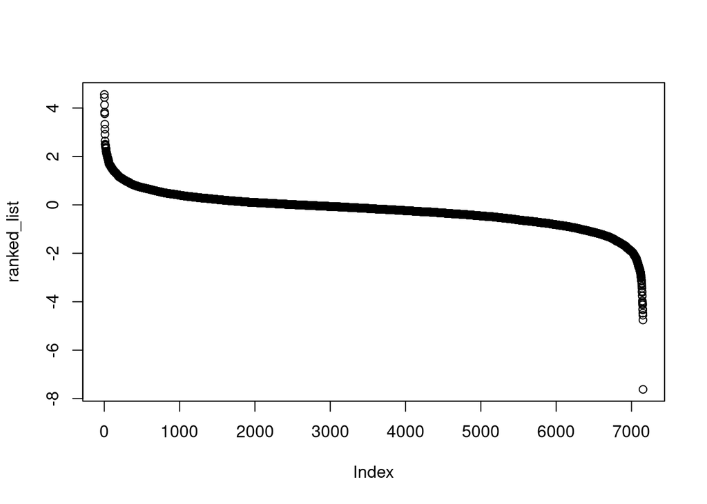

```r
plot(ranked_list) # each dot is a gene symbol, x index list of genes <8000, y = ranking
```

```r
# BSS version
# rankings <- sign(protein_list_a$log2fc)*(-log10(protein_list_a$pval))
# names(rankings) <- protein_list_a$SYMBOL # add gene symbol to value
# rankings <- sort(rankings, decreasing = TRUE) #sort by from largest pos to neg
# plot(rankings) # each dot is a gene symbol, x index list of genes <8000, y = ranking
# max(rankings) # max = 4.559848 | note we do not have Inf because already cleaned!
# min(rankings) # min = -7.619261 | fgsea() does not accept non-finite no. as rankings!
# # also see their version of removing infinite rankings on blog if needed!

# Squidtip - Another note on rankings… You can just use the log2(fold-change) as a ranking – but it will not take into account genes with a large fold change but non-significant. However, if you have already selected your significant genes, this may be a good option for you.
```

### 3. Run GSEA

```r
# run gsea with hallmark pathways!
GSEA_hm <- fgsea(pathways = gene_sets, # list of genes 2 check (50 hallmark genesets,
                 stats = ranked_list, # data were computing on
                 scoreType = 'std', #standard since we have positive & negitive
                 minSize = 15, # mini gene set size
                 maxSize = 500, # max gene set size
                 nproc = 1 # for parallelisation
                 )
```

[output not shown]

```r
# cant have NAs! also gives watning on preranked ties (only 0.73% of list - mostly ns)
# Note! Changing maxSize seems to affect pvalues?

head(GSEA_hm)
```

```
##                         pathway        pval       padj    log2err         ES
##                          <char>       <num>      <num>      <num>      <num>
## 1:        HALLMARK_ADIPOGENESIS 0.005464797 0.02853838 0.40701792  0.2996374
## 2: HALLMARK_ALLOGRAFT_REJECTION 0.674630262 0.84688233 0.03784877 -0.2955908
## 3:   HALLMARK_ANDROGEN_RESPONSE 0.012976162 0.06098796 0.38073040 -0.5066409
## 4:     HALLMARK_APICAL_JUNCTION 0.400848356 0.72925483 0.05859376 -0.3281940
## 5:      HALLMARK_APICAL_SURFACE 0.111111111 0.33662162 0.15016980 -0.5555036
## 6:           HALLMARK_APOPTOSIS 0.478500551 0.80319735 0.05216303 -0.3272548
##           NES  size  leadingEdge
##         <num> <int>       <list>
## 1:  1.3771608   135 Jagn1, U....
## 2: -0.8716885    50 Capg, Pr....
## 3: -1.4976653    51 Hmgcs1, ....
## 4: -1.0490615   105 Map3k20,....
## 5: -1.3603067    17 Scube1, ....
## 6: -0.9983566    67 Lmna, Ig....
```

```r
# # export GSEA msigdb hallmark results
# write_csv(GSEA_hm, "output/2025_09_22_GSEA_hm_results_EEvsSH_MSstatsTMT_v3.1.5_t8_BioIn_3.3.1_t1.csv")

# write_csv does not write leading edge?
```